# White Wine Quality Data Exploration by Wenny

Let’s look at the data and summary statistics:

```
## 'data.frame':    4898 obs. of  13 variables:
##  $ X                   : int  1 2 3 4 5 6 7 8 9 10 ...
##  $ fixed.acidity       : num  7 6.3 8.1 7.2 7.2 8.1 6.2 7 6.3 8.1 ...
##  $ volatile.acidity    : num  0.27 0.3 0.28 0.23 0.23 0.28 0.32 0.27 0.3 0.22 ...
##  $ citric.acid         : num  0.36 0.34 0.4 0.32 0.32 0.4 0.16 0.36 0.34 0.43 ...
##  $ residual.sugar      : num  20.7 1.6 6.9 8.5 8.5 6.9 7 20.7 1.6 1.5 ...
##  $ chlorides           : num  0.045 0.049 0.05 0.058 0.058 0.05 0.045 0.045 0.049 0.044 ...
##  $ free.sulfur.dioxide : num  45 14 30 47 47 30 30 45 14 28 ...
##  $ total.sulfur.dioxide: num  170 132 97 186 186 97 136 170 132 129 ...
##  $ density             : num  1.001 0.994 0.995 0.996 0.996 ...
##  $ pH                  : num  3 3.3 3.26 3.19 3.19 3.26 3.18 3 3.3 3.22 ...
##  $ sulphates           : num  0.45 0.49 0.44 0.4 0.4 0.44 0.47 0.45 0.49 0.45 ...
##  $ alcohol             : num  8.8 9.5 10.1 9.9 9.9 10.1 9.6 8.8 9.5 11 ...
##  $ quality             : int  6 6 6 6 6 6 6 6 6 6 ...
```

```
##  [1] "X"                    "fixed.acidity"        "volatile.acidity"
##  [4] "citric.acid"          "residual.sugar"       "chlorides"
##  [7] "free.sulfur.dioxide"  "total.sulfur.dioxide" "density"
## [10] "pH"                   "sulphates"            "alcohol"
## [13] "quality"
```

```
##        X        fixed.acidity    volatile.acidity  citric.acid
##  Min.   :   1   Min.   : 3.800   Min.   :0.0800   Min.   :0.0000
##  1st Qu.:1225   1st Qu.: 6.300   1st Qu.:0.2100   1st Qu.:0.2700
##  Median :2450   Median : 6.800   Median :0.2600   Median :0.3200
##  Mean   :2450   Mean   : 6.855   Mean   :0.2782   Mean   :0.3342
##  3rd Qu.:3674   3rd Qu.: 7.300   3rd Qu.:0.3200   3rd Qu.:0.3900
##  Max.   :4898   Max.   :14.200   Max.   :1.1000   Max.   :1.6600
##  residual.sugar     chlorides       free.sulfur.dioxide
##  Min.   : 0.600   Min.   :0.00900   Min.   :  2.00
##  1st Qu.: 1.700   1st Qu.:0.03600   1st Qu.: 23.00
##  Median : 5.200   Median :0.04300   Median : 34.00
##  Mean   : 6.391   Mean   :0.04577   Mean   : 35.31
##  3rd Qu.: 9.900   3rd Qu.:0.05000   3rd Qu.: 46.00
##  Max.   :65.800   Max.   :0.34600   Max.   :289.00
##  total.sulfur.dioxide    density             pH          sulphates
##  Min.   :  9.0        Min.   :0.9871   Min.   :2.720   Min.   :0.2200
##  1st Qu.:108.0        1st Qu.:0.9917   1st Qu.:3.090   1st Qu.:0.4100
##  Median :134.0        Median :0.9937   Median :3.180   Median :0.4700
##  Mean   :138.4        Mean   :0.9940   Mean   :3.188   Mean   :0.4898
##  3rd Qu.:167.0        3rd Qu.:0.9961   3rd Qu.:3.280   3rd Qu.:0.5500
##  Max.   :440.0        Max.   :1.0390   Max.   :3.820   Max.   :1.0800
##     alcohol         quality
##  Min.   : 8.00   Min.   :3.000
##  1st Qu.: 9.50   1st Qu.:5.000
##  Median :10.40   Median :6.000
##  Mean   :10.51   Mean   :5.878
##  3rd Qu.:11.40   3rd Qu.:6.000
##  Max.   :14.20   Max.   :9.000
```

# Univariate Plots Section

Let’s look at the distribution of quality ratings and chemical properties.

Most wines received a quality rating of 5 or 6. All quality ratings were between 3 and 9.

```
##    Min. 1st Qu.  Median    Mean 3rd Qu.    Max.
##   3.000   5.000   6.000   5.878   6.000   9.000
```

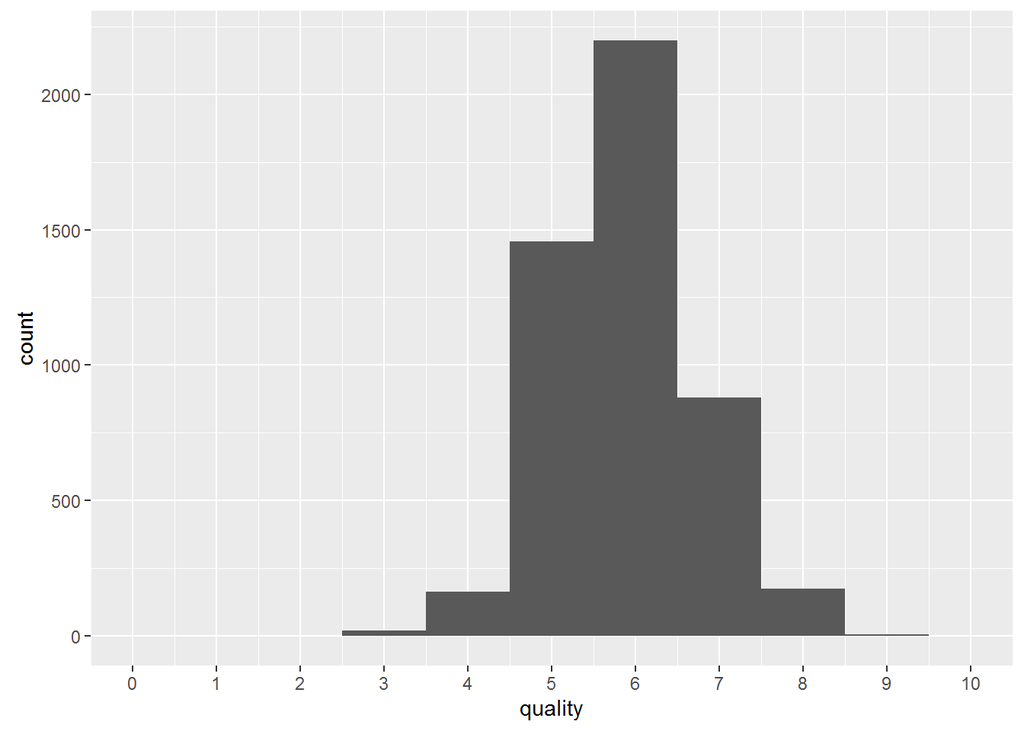

Fixed acidity values were between 3.8 and 14.2. I used log10 to see the distribution clearer, and removed outliers (values < 4.8 and > 8.8).

```
##    Min. 1st Qu.  Median    Mean 3rd Qu.    Max.
##   3.800   6.300   6.800   6.855   7.300  14.200
```

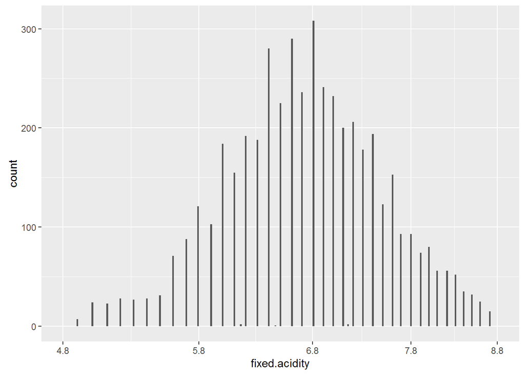

Volatile acidity values were betwwen 0.08 and 1.1. I used log10 to see the distribution clearer, and removed outliers (values > 0.485).

```
##    Min. 1st Qu.  Median    Mean 3rd Qu.    Max.
##  0.0800  0.2100  0.2600  0.2782  0.3200  1.1000
```

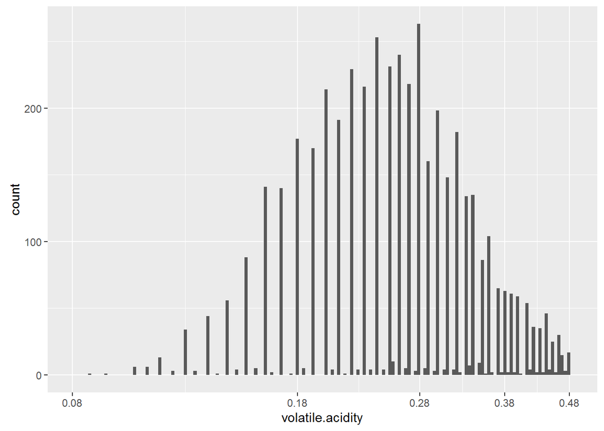

Citric acid values were between 0 and 1.66. I used log10 to see the distribution clearer, and removed outliers (values < 0.09 and > 0.57).

```
##    Min. 1st Qu.  Median    Mean 3rd Qu.    Max.
##  0.0000  0.2700  0.3200  0.3342  0.3900  1.6600
```

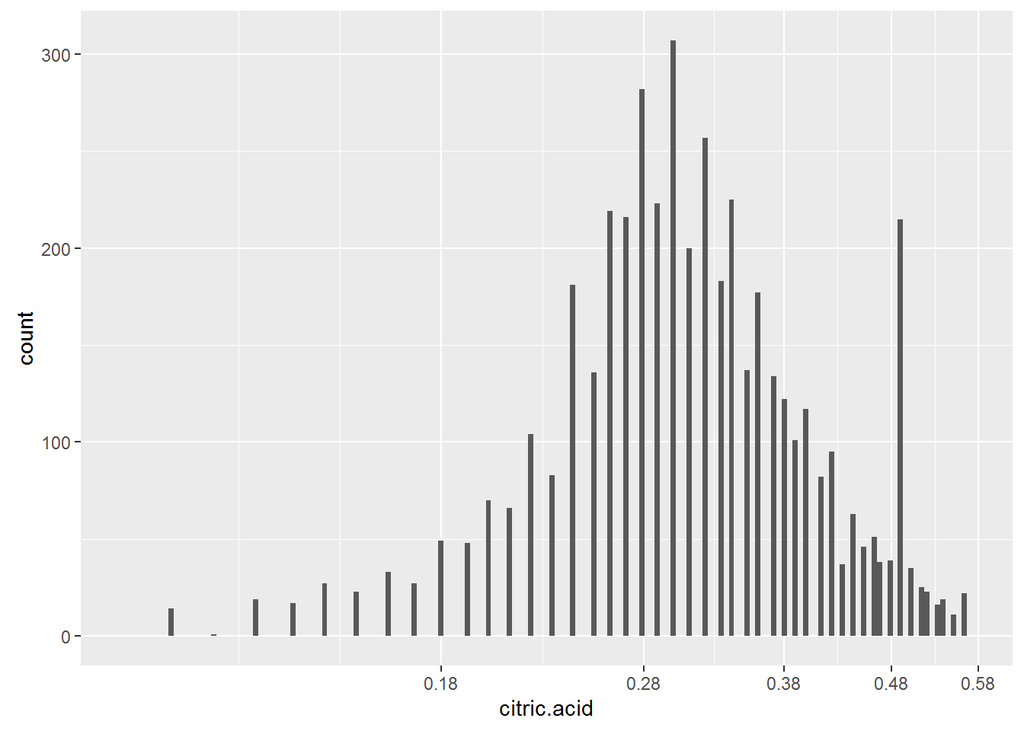

Residual sugar values were between 0.6 and 65.8. I used log10 to see the distribution clearer, and removed outliers (values > 22.2). The distribution appears bimodal.

```
##    Min. 1st Qu.  Median    Mean 3rd Qu.    Max.
##   0.600   1.700   5.200   6.391   9.900  65.800
```

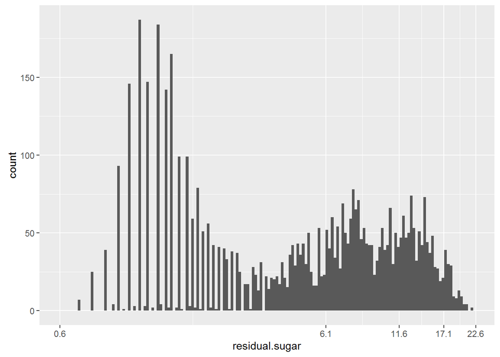

```
##    Min. 1st Qu.  Median    Mean 3rd Qu.    Max.
## 0.00900 0.03600 0.04300 0.04577 0.05000 0.34600
```

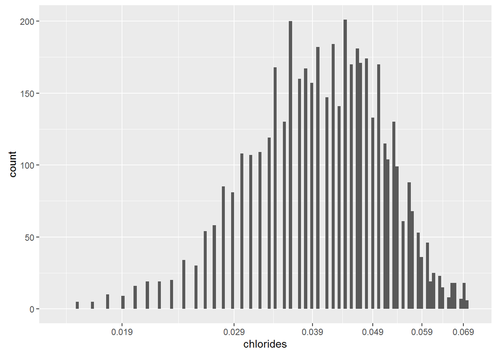

```
##    Min. 1st Qu.  Median    Mean 3rd Qu.    Max.
##    2.00   23.00   34.00   35.31   46.00  289.00
```

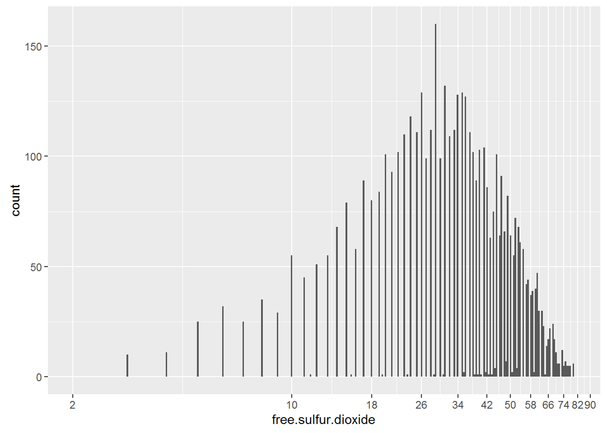

```
##    Min. 1st Qu.  Median    Mean 3rd Qu.    Max.
##     9.0   108.0   134.0   138.4   167.0   440.0
```

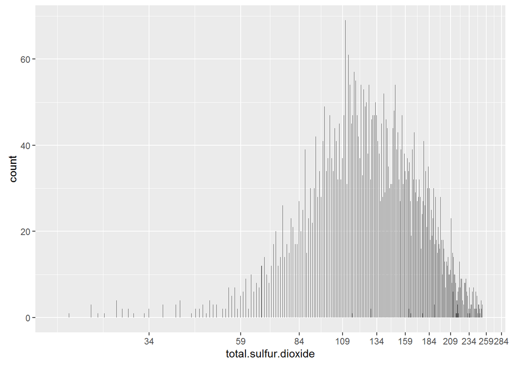

Density values were between 0.987 and 1.039 I used log10 to see the distribution clearer, and removed outliers (values > 1.003). The distribution seems scattered.

```
##    Min. 1st Qu.  Median    Mean 3rd Qu.    Max.
##  0.9871  0.9917  0.9937  0.9940  0.9961  1.0390
```

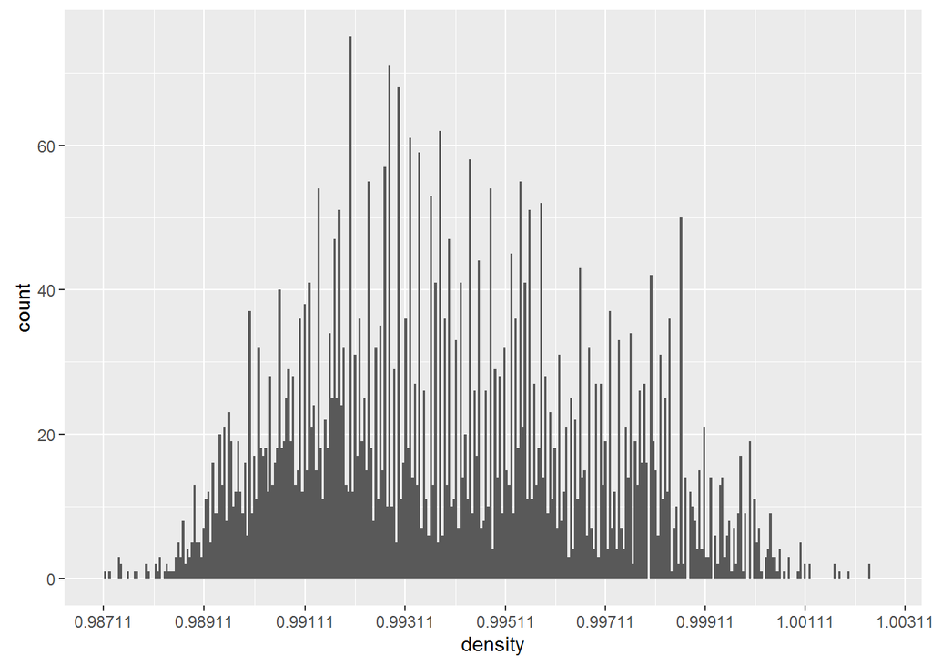

pH values were between 2.72 and 3.82. I removed outliers (values < 2.805 and > 3.565).

```
##    Min. 1st Qu.  Median    Mean 3rd Qu.    Max.
##   2.720   3.090   3.180   3.188   3.280   3.820
```

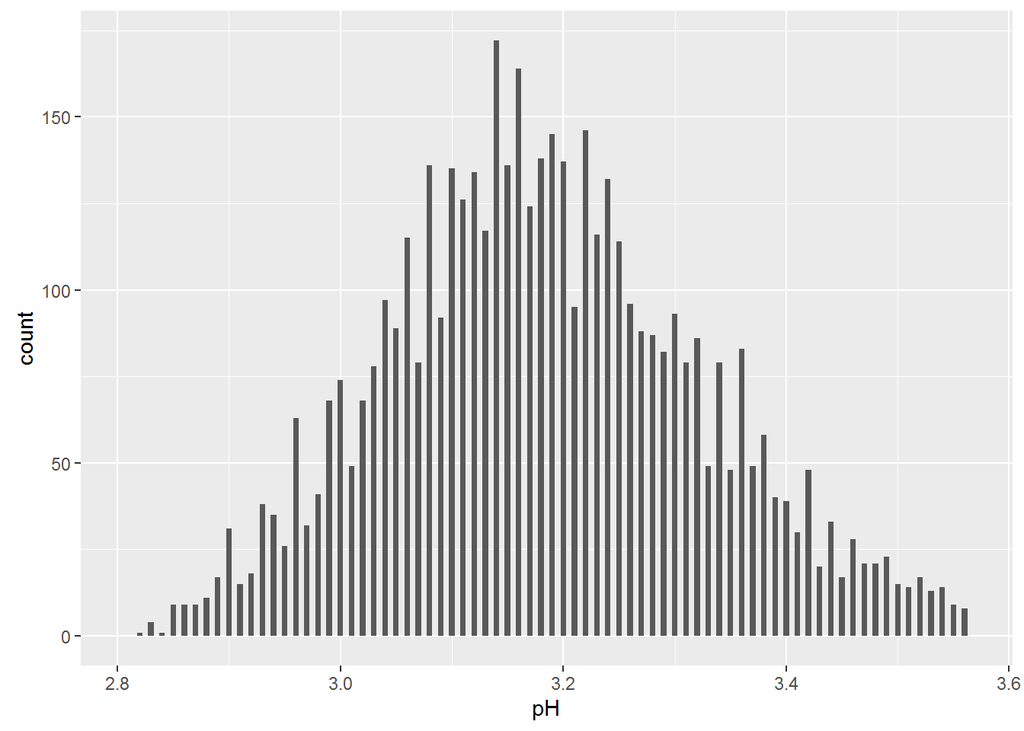

Sulphate values were between 0.22 and 1.08. I removed outliers (values > 0.76).

```
##    Min. 1st Qu.  Median    Mean 3rd Qu.    Max.
##  0.2200  0.4100  0.4700  0.4898  0.5500  1.0800
```

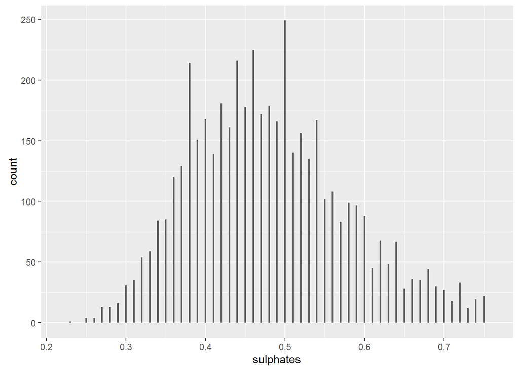

```
##    Min. 1st Qu.  Median    Mean 3rd Qu.    Max.
##    8.00    9.50   10.40   10.51   11.40   14.20
```

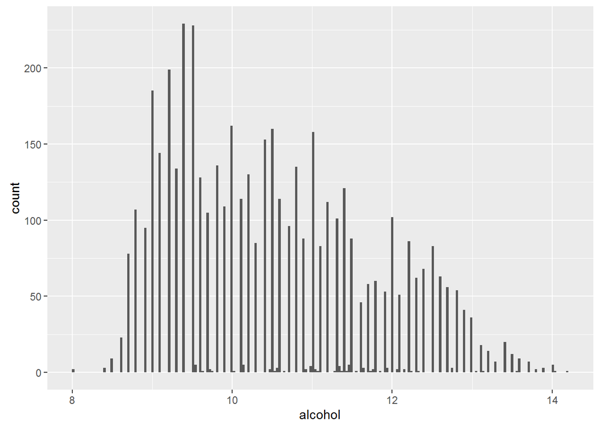

# Univariate Analysis

### What is the structure of your dataset?

The dataframe contains 4,898 observations and 11 variables related to chemical properties of each wine: fixed acidity, volatile acidity, citric acid, residual sugar, chlorides, free sulfur dioxide, total sulfur dioxide, density, pH, sulphates, and alcohol content. At least 3 wine experts rated the quality of each wine, with 0 as the lowest rating and 10 as the highest rating.

### What is/are the main feature(s) of interest in your dataset?

Most wines had a quality rating of 5 or 6. Residual sugar appears to have a bimodal distribution. Density and alcohol both show wide scattered distributions.

### What other features in the dataset do you think will help support your investigation into your feature(s) of interest?

Understanding correlations between the different features.

### Did you create any new variables from existing variables in the dataset?

No

### Of the features you investigated, were there any unusual distributions? Did you perform any operations on the data to tidy, adjust, or change the form of the data? If so, why did you do this?

Residual sugar has a bimodal distribution. A log10 scale was applied to all the plots of the chemical properties, except those for pH, sulphates, and alcohol, to better view the distribution. Outliers for the distributions of chemical properties were identified and removed.

# Bivariate Plots Section

Let’s look to see if chemical properties of white wine are correlated.

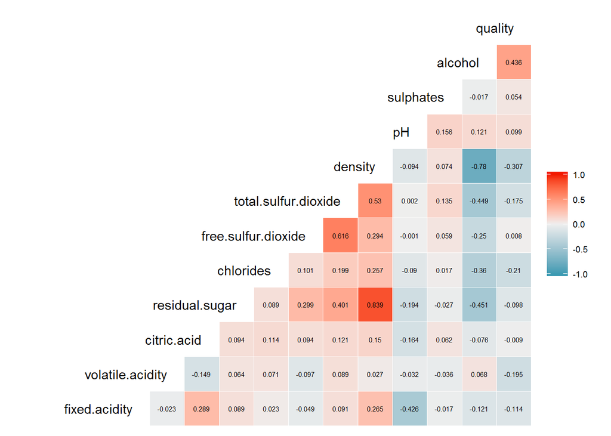

Let’s look at some of the relationships between these variables.

Alcohol content was the chemical property with the highest (positive) correlation to wine quality. Wines with higher quality ratings tended to have higher alcohol content.

```
## [1] 0.4355747
```

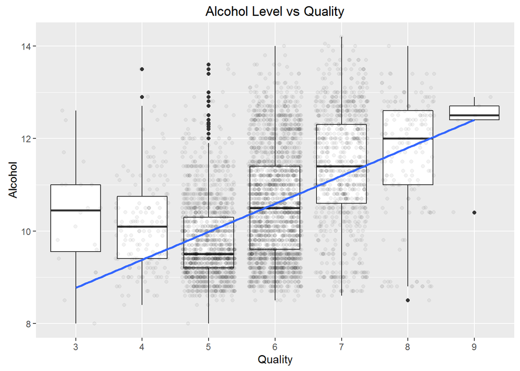

Density was slightly negatively correlated with wine quality.

```
## [1] -0.3071233
```

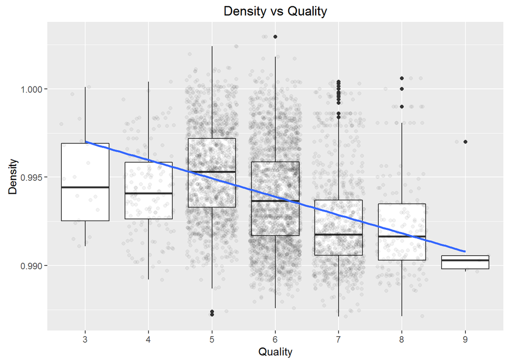

Alcohol and density showed a negative correlation.

```
## [1] -0.7801376
```

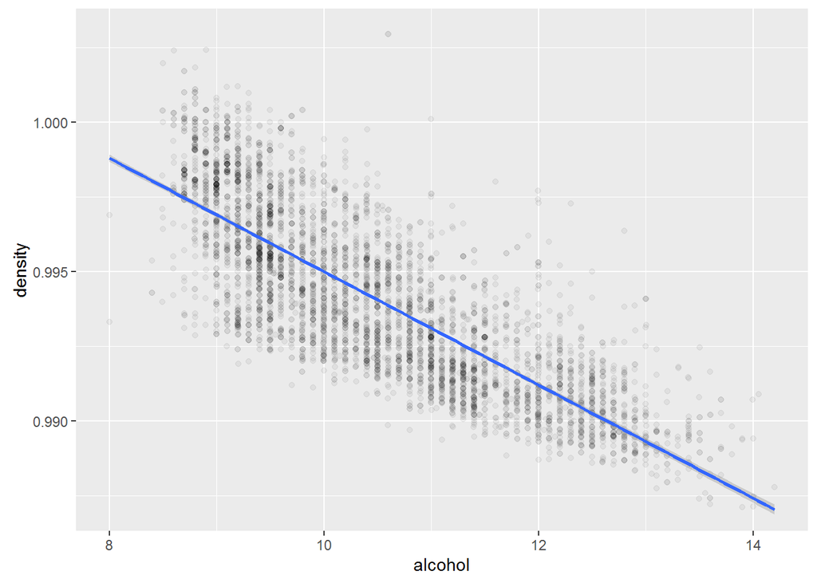

Density and residual sugar showed the highest overall correlation amongst the chemical properties provided for white wine.

```
## [1] 0.8389665
```

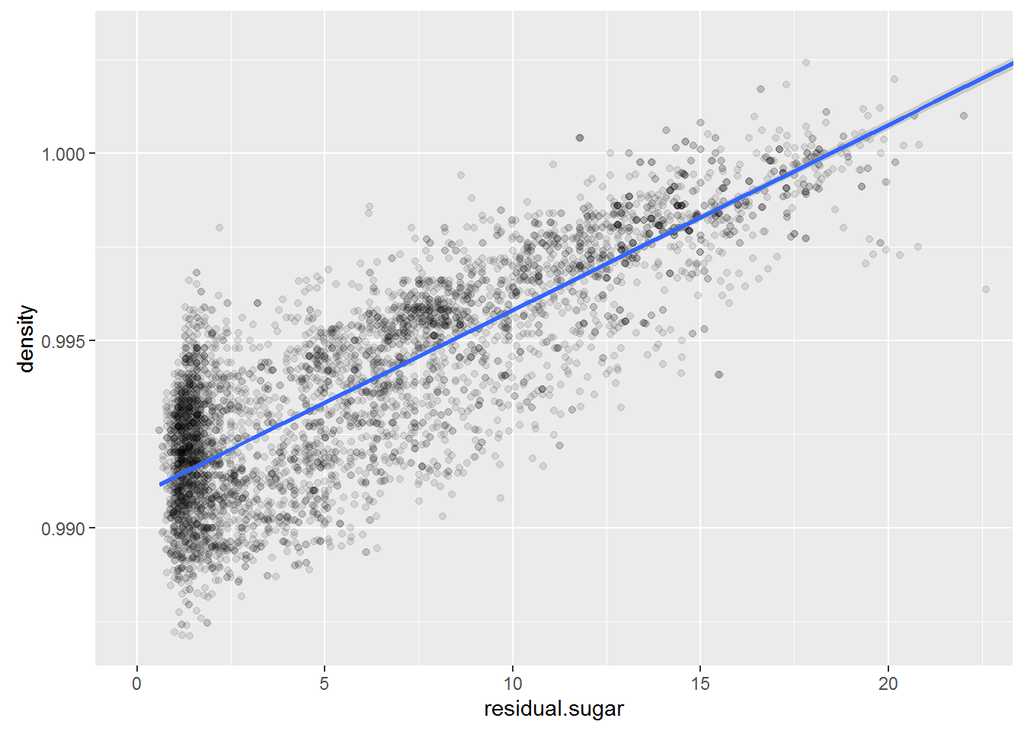

Free sulfur dioxide is positively correlated with total sulfur dioxide.

```
## [1] 0.615501
```

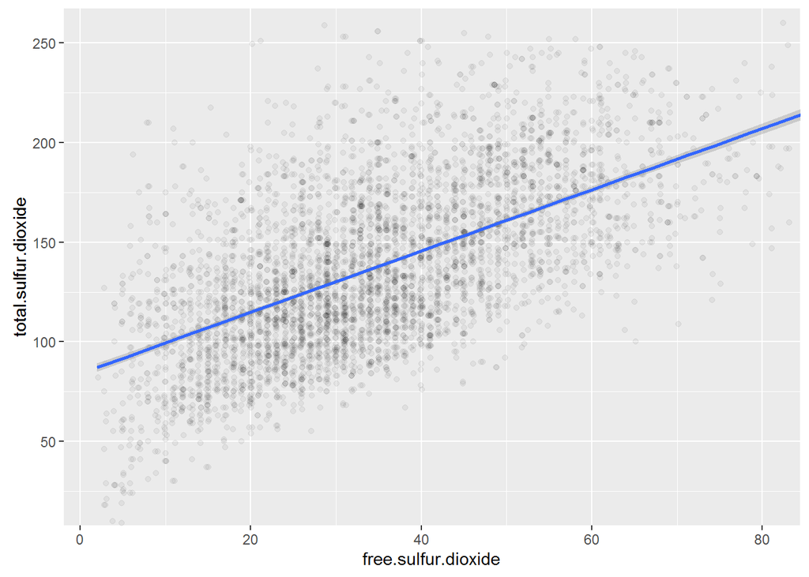

Fixed acidity is negatively correlated with pH.

```
## [1] -0.4258583
```

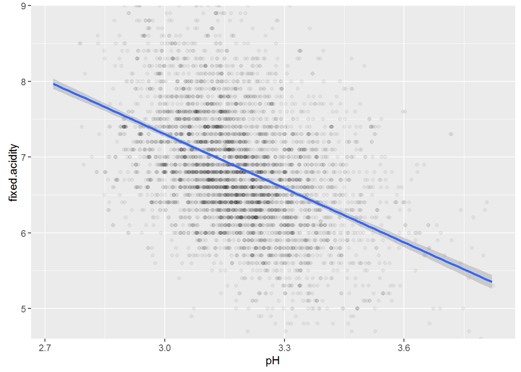

# Bivariate Analysis

### Talk about some of the relationships you observed in this part of the investigation. How did the feature(s) of interest vary with other features in the dataset?

White wines with higher alcohol content tended to receive higher quality ratings. Alcohol was negatively correlated with density, and density is highly correlated with residual sugar content.

### Did you observe any interesting relationships between the other features (not the main feature(s) of interest)?

Many of the variables did not have strong correlations with each other, and quality was not very highly correlated with any of the chemical properties.

### What was the strongest relationship you found?

Density and residual sugar had a correlation coefficient of 0.839.

# Multivariate Plots Section

Run a simple linear regression with all variables.

```
##
## Call:
## lm(formula = quality ~ alcohol + chlorides + citric.acid + density +
##     fixed.acidity + free.sulfur.dioxide + pH + residual.sugar +
##     sulphates + total.sulfur.dioxide + volatile.acidity)
##
## Residuals:
##     Min      1Q  Median      3Q     Max
## -3.8348 -0.4934 -0.0379  0.4637  3.1143
##
## Coefficients:
##                        Estimate Std. Error t value Pr(>|t|)
## (Intercept)           1.502e+02  1.880e+01   7.987 1.71e-15 ***
## alcohol               1.935e-01  2.422e-02   7.988 1.70e-15 ***
## chlorides            -2.473e-01  5.465e-01  -0.452  0.65097
## citric.acid           2.209e-02  9.577e-02   0.231  0.81759
## density              -1.503e+02  1.907e+01  -7.879 4.04e-15 ***
## fixed.acidity         6.552e-02  2.087e-02   3.139  0.00171 **
## free.sulfur.dioxide   3.733e-03  8.441e-04   4.422 9.99e-06 ***
## pH                    6.863e-01  1.054e-01   6.513 8.10e-11 ***
## residual.sugar        8.148e-02  7.527e-03  10.825  < 2e-16 ***
## sulphates             6.315e-01  1.004e-01   6.291 3.44e-10 ***
## total.sulfur.dioxide -2.857e-04  3.781e-04  -0.756  0.44979
## volatile.acidity     -1.863e+00  1.138e-01 -16.373  < 2e-16 ***
## ---
## Signif. codes:  0 '***' 0.001 '**' 0.01 '*' 0.05 '.' 0.1 ' ' 1
##
## Residual standard error: 0.7514 on 4886 degrees of freedom
## Multiple R-squared:  0.2819, Adjusted R-squared:  0.2803
## F-statistic: 174.3 on 11 and 4886 DF,  p-value: < 2.2e-16
```

Chlorides, citric acid, and total sulfur dioxide are not statistically significant. Remove these variables from the linear regression model.

```
##
## Call:
## lm(formula = quality ~ alcohol + density + fixed.acidity + free.sulfur.dioxide +
##     pH + residual.sugar + sulphates + volatile.acidity)
##
## Residuals:
##     Min      1Q  Median      3Q     Max
## -3.8246 -0.4938 -0.0396  0.4660  3.1208
##
## Coefficients:
##                       Estimate Std. Error t value Pr(>|t|)
## (Intercept)          1.541e+02  1.810e+01   8.514  < 2e-16 ***
## alcohol              1.932e-01  2.408e-02   8.021 1.31e-15 ***
## density             -1.543e+02  1.834e+01  -8.411  < 2e-16 ***
## fixed.acidity        6.810e-02  2.043e-02   3.333 0.000864 ***
## free.sulfur.dioxide  3.349e-03  6.766e-04   4.950 7.67e-07 ***
## pH                   6.942e-01  1.034e-01   6.717 2.07e-11 ***
## residual.sugar       8.285e-02  7.287e-03  11.370  < 2e-16 ***
## sulphates            6.285e-01  9.997e-02   6.287 3.52e-10 ***
## volatile.acidity    -1.888e+00  1.095e-01 -17.242  < 2e-16 ***
## ---
## Signif. codes:  0 '***' 0.001 '**' 0.01 '*' 0.05 '.' 0.1 ' ' 1
##
## Residual standard error: 0.7512 on 4889 degrees of freedom
## Multiple R-squared:  0.2818, Adjusted R-squared:  0.2806
## F-statistic: 239.7 on 8 and 4889 DF,  p-value: < 2.2e-16
```

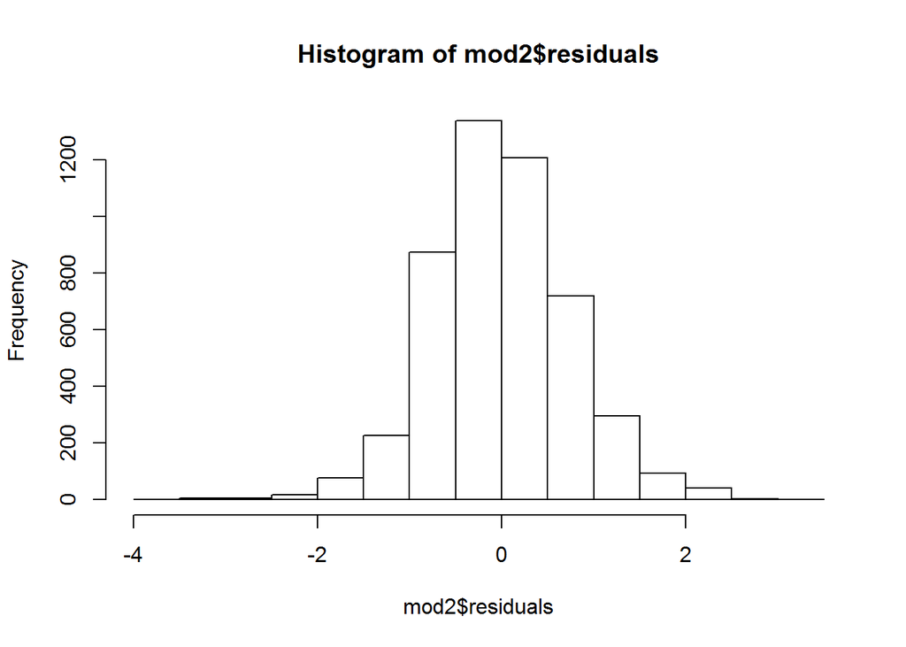

Let’s see how density and alcohol content relate to wine quality.

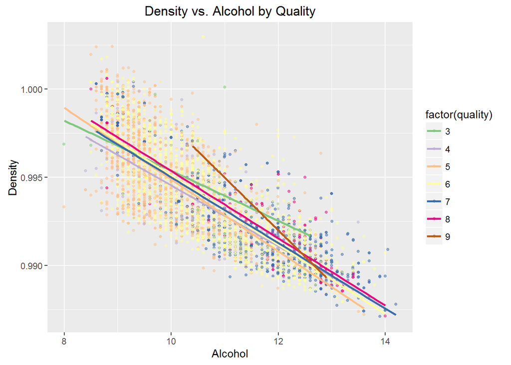

# Multivariate Analysis

### Talk about some of the relationships you observed in this part of the investigation. Were there features that strengthened each other in terms of looking at your feature(s) of interest?

The simple linear regression model shows chlorides, citric acid, and total sulfur dioxide are not statistically significant.

### Were there any interesting or surprising interactions between features?

Higher quality wines had higher alcohol content/lower wine densities.

### OPTIONAL: Did you create any models with your dataset? Discuss the strengths and limitations of your model.

I ran a simple linear regression model, adding all the chemical properties together, to determine which chemical properties were statistically significant. The model is limited in that it may not capture more complex interactions between features.

# Final Plots and Summary

### Plot One: Quality of White Wine

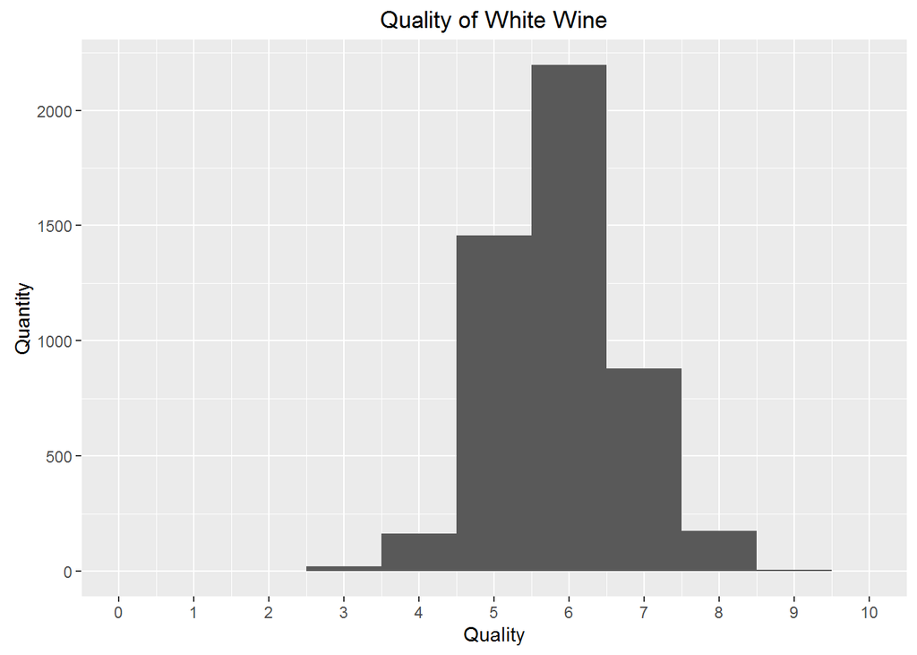

### Description One

Let’s revisit the quality of the white wines. The histogram of quality ratings shows most white wines received a rating of 5 or 6.

### Plot Two: Alcohol Level vs Quality

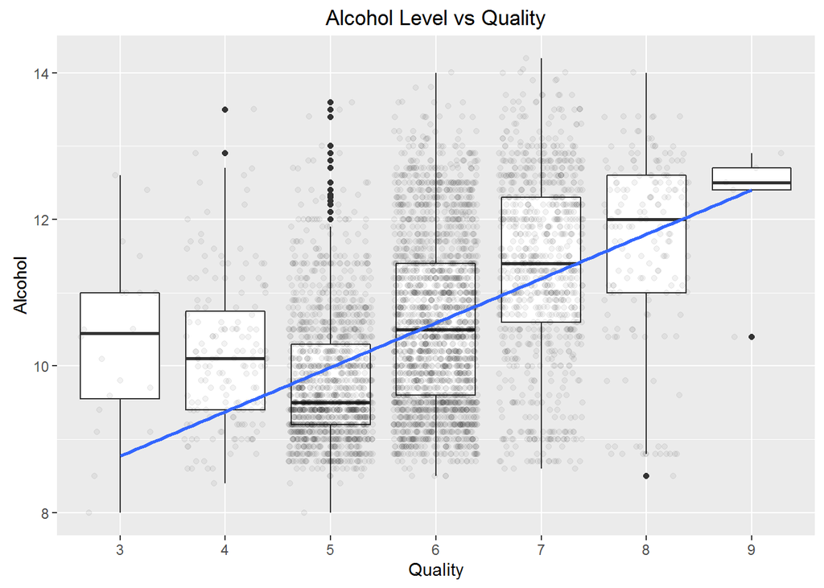

### Description Two

Looking at relationships between wine quality and chemical properties, it appears white wines with higher alcohol content tended to receive higher quality ratings.

### Plot Three: Density vs Alcohol by Quality

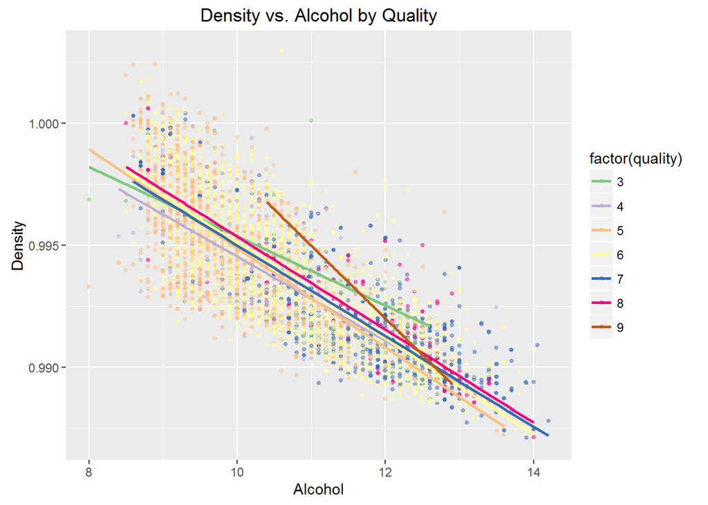

### Description Three

Density is negatively correlated with alcohol content (-0.780), and we can see again that white wines with higher quality ratings have higher alcohol content and lower densitites.

# Reflection

##### For future exploration, I would like to dive further into the wines in each quality rating category, searching for patterns amongst the chemical properties. I would also like to find data on vintage (year and region) and grape varietal to see if wines of a certain vintage or varietal tend to receive higher ratings.

##### Throughout this data exploration process, I found challenges in creating proper visualizations to depict the data relationships I was investigating. I had to frequently adjust scales, remove outliers, and adjust font sizes and binwidths to make the data more readable. I switched my ggpairs chart to ggcorr to better read the correlations between the different variables.

#### References:

#### https://rstudio-pubs-static.s3.amazonaws.com/64329_b0ed679e48b04f00a404f6f969d855d7.html

#### https://rpubs.com/Daria/57835

#### http://docs.ggplot2.org/current/aes_group_order.html